# Public Bus Trip Observations: Comfort, Crowding, and Behavior

Lindi Zhang

## Comfort under Different Bus Crowding Levels

This plot shows how comfort ratings vary depending on how crowded the bus is.

We can observe that the comfort level tends to decrease as the bus becomes more full.

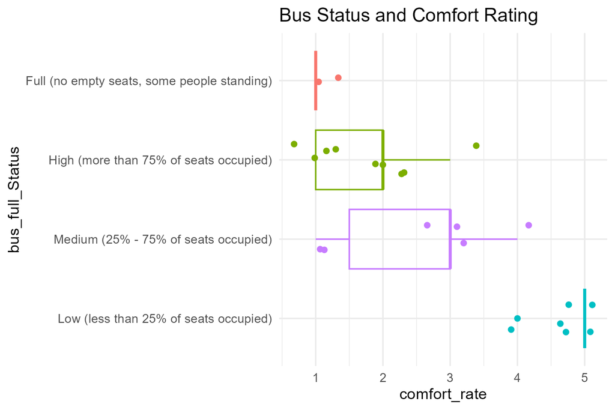

Boxplot of comfort by bus occupancy level. Comfort is lowest when the bus is full.

## Headphone Use among Passengers

This bar chart shows how many people were wearing headphones.

Most passengers were wearing headphones sometimes, with fewer wearing them all the time or not at all.

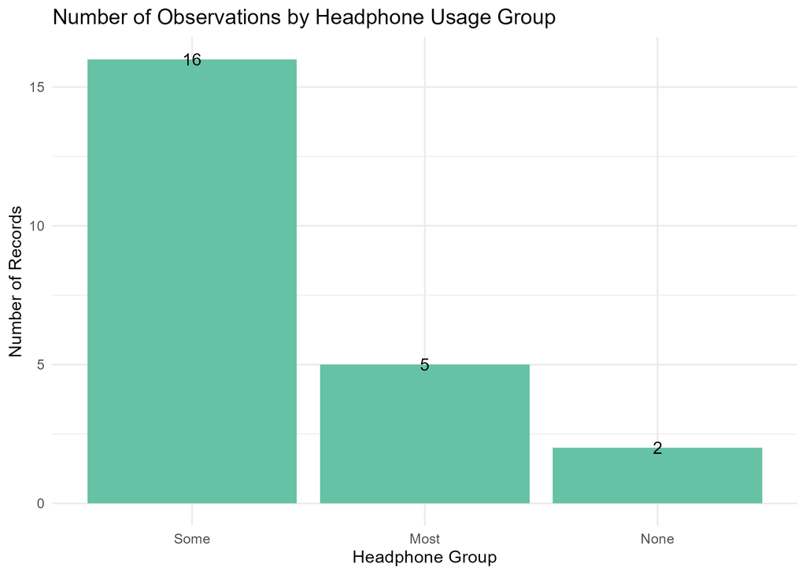

Bar chart of headphone usage groups. “Some” is the most common category.

## Comfort Ratings by Time of Day

This chart shows the average comfort score at different times of the day.

It reveals a pattern where comfort may depend on time, may be due to congestion, or may depend on the morning rush hour, evening rush hour, etc.

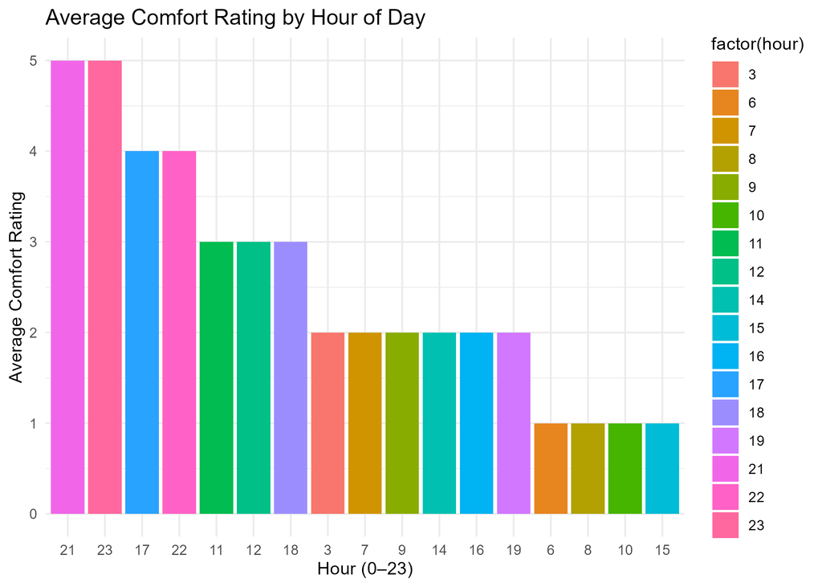

Bar chart of average comfort per hour. Comfort varies across the day.

## Eating Behavior by Hour of Day

This visualization shows how often eating behavior was observed on the bus at different times of the day.

To create this, I extracted the hour from the time_stamp using `mutate(hour = hour(...))`, then summarized the data using `count(hour, eat_or_not)`. I used `facet_wrap("eat_or_not")` to split the plot into two separate graph: one for observations which eating was seen (`Yes`) and another which eating was not (`No`).

This picture is helpful for comparing the time of eating behavior and non-eating behavior when taking a vehicle. We can see that it is easier to observe eating at 11 a.m. while it is more common for people not to eat at 11 p.m.

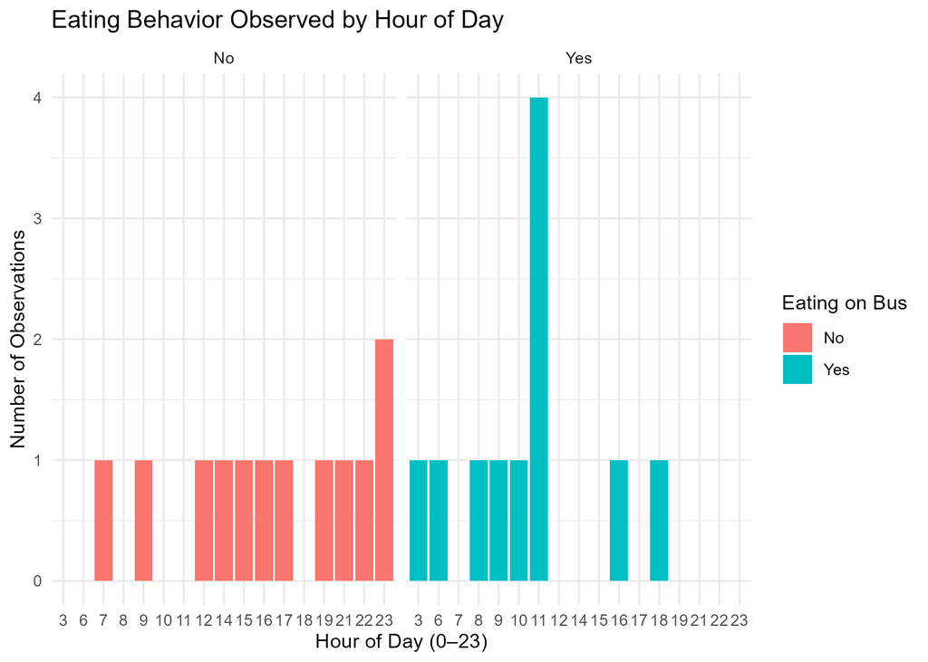